# Predictiing Brain Stroke counts by Analyzing `Brain Stroke Dataset`

Math-7360, Data Analysis Project

Moslem Uddin[^1]

Naufil Sakran[^2]

Abstract

In this report, we will analyze the factors associated with brain stroke disease. We have a dataset consisting of 4981 individuals with various information related to gender, health condition(information about a few other diseases), work type, and geographical information. We would like to identify whether any correlation exists among stroke with gender, work type, and other diseases.

# Introduction

In this project, we intend to analyze the (*Brain Stroke Dataset*, n.d.) corresponding to brain stroke disease. A stroke is a medical condition in which poor blood flow to the brain causes cell death. There are mainly two main types of strokes: ischemic and hemorrhagic. Doctors have associated the cause of brain stroke with several factors, such as medical conditions, occupation, type of residence, marital status, and smoking. We intend to show if there is any correlation between these attributes and brain stroke.

The dataset provides attribute information about the patient, which includes:

1. Gender,
2. Age,
3. Whether the patient has Hypertension,
4. Whether the patient has heart disease,
5. Work type,
6. Average glucose level,
7. Body mass index,
8. Whether the patient smokes,
9. Whether the patient has strokes.

In the project, we will give the correlation between these attributes, applying statistics-related fields ( that is, regression analysis and neural network to classify stroke counts between different variables. This will further help observe whether any of the attributes contribute to increasing the chances of brain stroke. In other words, we want to find out the dominating factors leading to brain stroke by fitting models with various combinations of causes. To accomplish this goal, we first perform data cleansing and then study different models formed with various combinations of factors, considering various algorithms.

We believe that analyzing this dataset will allow us to understand how the knowledge gained from the data analysis can be utilized to detect causes that amplify the risk of this fatal disease. Later, we’ll be able to apply this process to study other related areas. Further, this study can enable collaboration with researchers from fields of biology and medical sciences to examine related topics.

# Overview of Dataset

The following table provides a summary of our dataset. The rows of the column depicts the proportion of gender impacted by the variables. For instance, in the row of `heart_disease`, the number `112 (3.9%)` indicates 112 women out of 2907 have hear disease.

Table 1. Summary of Dataset

| **Variable** | **N** | **Overall**, N = 4,981<sup>1</sup> | **Gender** **Female**, N = 2,907<sup>1</sup> | **Gender** **Male**, N = 2,074<sup>1</sup> |
| --- | --- | --- | --- | --- |
| age | 4,981 | 45 (25, 61) | 45 (27, 61) | 46 (22, 61) |
| hypertension | 4,981 | 479 (9.6%) | 264 (9.1%) | 215 (10%) |
| heart_disease | 4,981 | 275 (5.5%) | 112 (3.9%) | 163 (7.9%) |
| ever_married | 4,981 | 3,280 (66%) | 1,948 (67%) | 1,332 (64%) |
| work_type | 4,981 |  |  |  |
| children |  | 673 (14%) | 317 (11%) | 356 (17%) |
| Govt_job |  | 644 (13%) | 390 (13%) | 254 (12%) |
| Private |  | 2,860 (57%) | 1,704 (59%) | 1,156 (56%) |
| Self-employed |  | 804 (16%) | 496 (17%) | 308 (15%) |
| Residence_type | 4,981 |  |  |  |
| Rural |  | 2,449 (49%) | 1,424 (49%) | 1,025 (49%) |
| Urban |  | 2,532 (51%) | 1,483 (51%) | 1,049 (51%) |
| avg_glucose_level | 4,981 | 92 (77, 114) | 91 (76, 112) | 94 (78, 117) |
| bmi | 4,981 | 28 (24, 33) | 28 (23, 33) | 29 (24, 32) |
| smoking_status | 4,981 |  |  |  |
| formerly smoked |  | 867 (17%) | 464 (16%) | 403 (19%) |
| never smoked |  | 1,838 (37%) | 1,194 (41%) | 644 (31%) |
| smokes |  | 776 (16%) | 441 (15%) | 335 (16%) |
| Unknown |  | 1,500 (30%) | 808 (28%) | 692 (33%) |
| stroke | 4,981 | 248 (5.0%) | 140 (4.8%) | 108 (5.2%) |

<sup>1</sup> Median (IQR) or Frequency (%)

# Graphical Analysis

In this section, we provide graphical correlation between different attributes that has hypothetical connection with brain stroke. The aim is to give pictorial description of the correlation with the variables.

## Correlartion plot

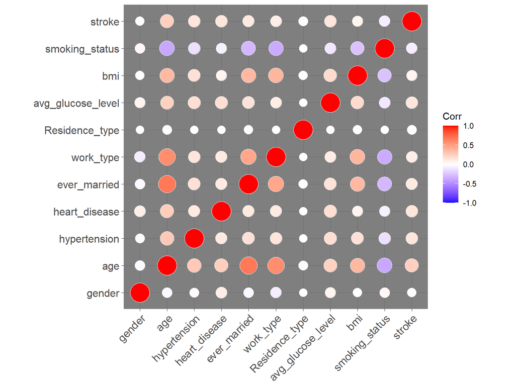

## Stroke counts considering various factors. (numerical observations)

The following picture shows the relation between age and percentage of people having brain stroke. It indicates that older population tend to have brain stroke.

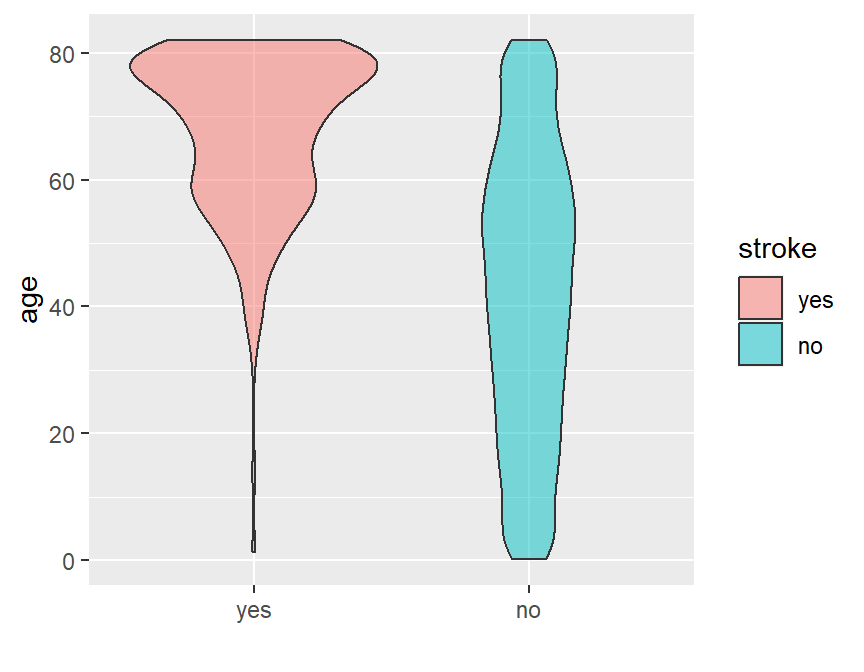

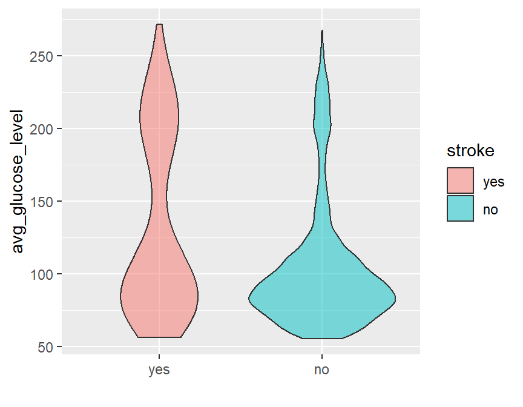

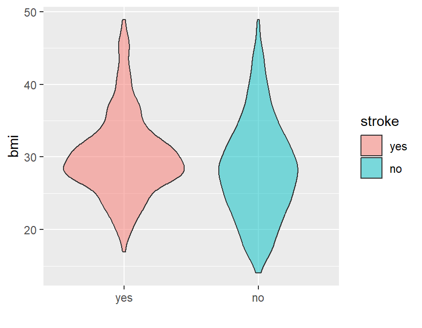

## Based various catagories

The following bar chart shows the proportion of brain stroke among various qualitative categories such as residence type, work type marital status and etc.

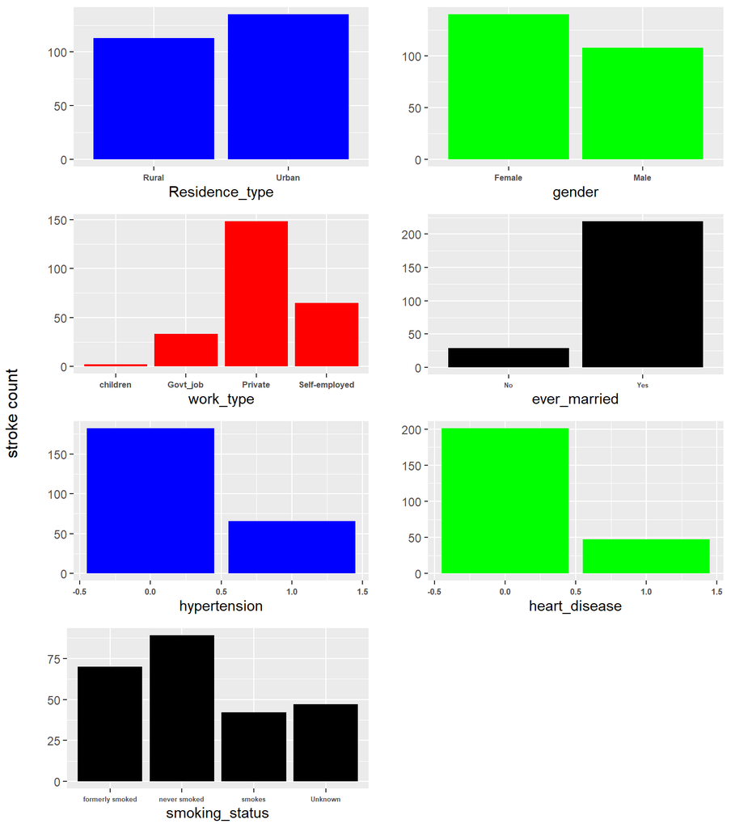

## Divided by gender

The following graph categorizes the stroke count with respect to gender. It displays the impact of variables on stroke count based on gender identification. The following graphs show how age is correlated with stroke count based on gender. The plot indicates the impact of age factor on stroke count is independent of gender.

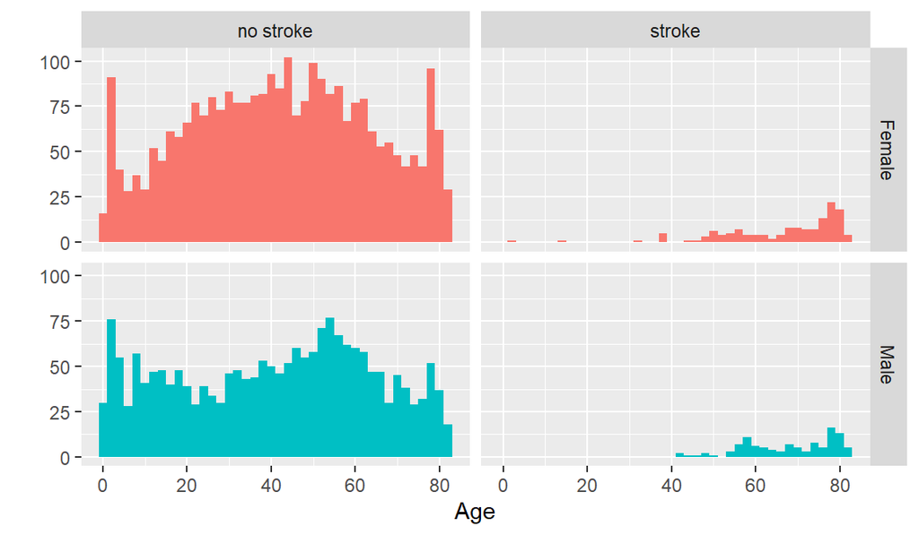

The following graphs show how average glucose level is correlated with stroke count based on gender. The plot indicates the impact of the average glucose level on stroke count is slightly higher for females as compared to male.

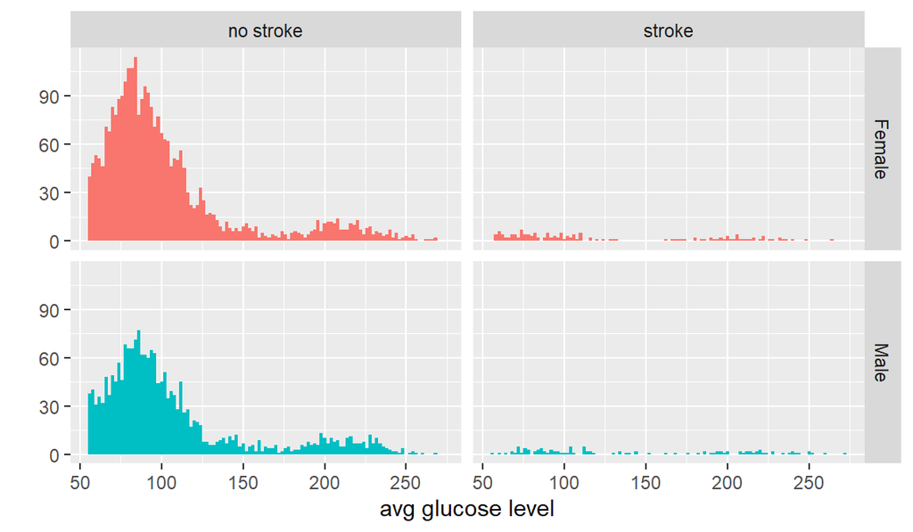

The following graphs show how body mass index is correlated with stroke count based on gender. The plot indicates the impact of body mass indices on stroke count are independent of gender.

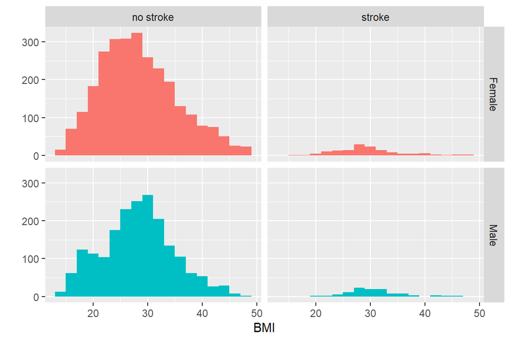

# Fitting Logistic model

- Based on graphical analysis, we would like to predict stroke counts using some dominant features using logistic regression
- we considered `stroke ~ age + avg_glucose_level + heart_disease + hypertension + ever_married’
- we’ve split data into test(25%) and train(75%) set

```
## [1] "Accuracy in test set=  0.938152610441767"
```

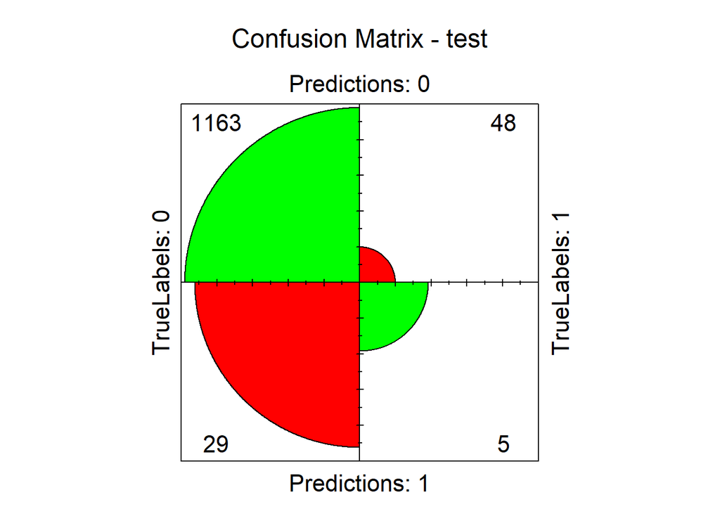

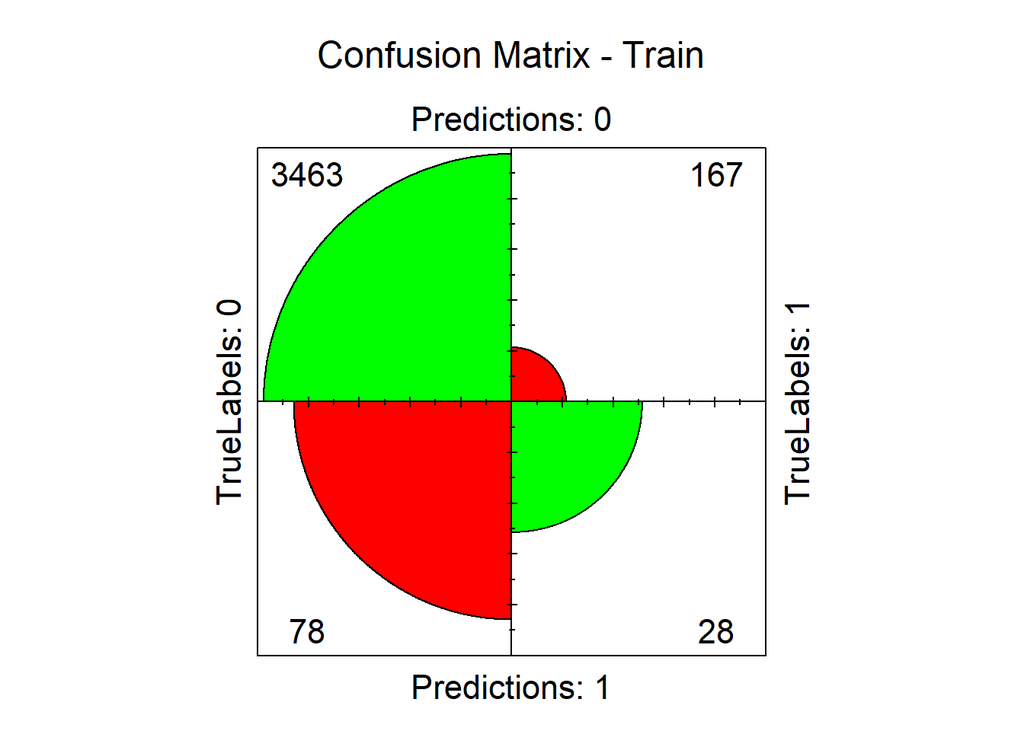

```
## [1] "Accuracy in training set=  0.934421841541756"
```

# Prediction using neural network

- We’ve also considered neural network using *deepnet* library to predict of stroke counts
- We’ve one hidden layer of 5 nodes
- we’ve considered full model

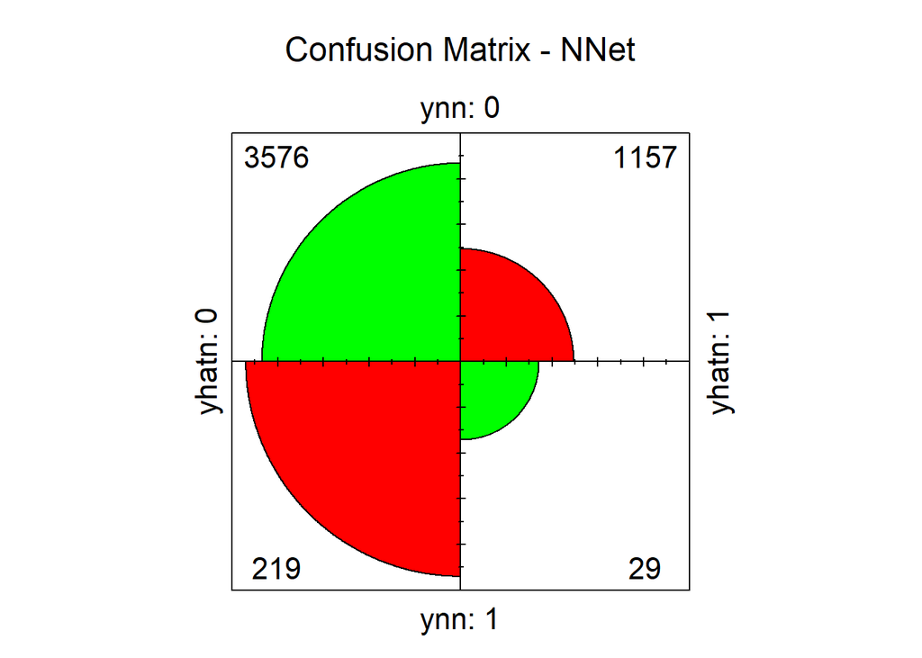

```
## [1] "Accuracy is=  0.723750250953624"
```

# Concluding remarks

- We’ve graphically analyzed ‘brain stroke dataset’
- utilized logistic regression and neural network to see how well we can predict stroke counts

## References

- Brain Stroke Dataset. n.d. https://www.kaggle.com/datasets/jillanisofttech/brain-stroke-dataset.
- Murphy, S. J., & Werring, D. J. (2020). Stroke: causes and clinical features. Medicine, 48(9), 561-566.
- Silva, G. S., Koroshetz, W. J., González, R. G., & Schwamm, L. H. (2011). Causes of ischemic stroke. Acute Ischemic Stroke: Imaging and Intervention, 25-42.
- Faraway, J.J. (2016). Extending the Linear Model with R: Generalized Linear, Mixed Effects and Nonparametric Regression Models, Second Edition (2nd ed.). Chapman and Hall/CRC. https://doi.org/10.1201/9781315382722
- Unwin(2015). Graphical Data Analysis with R. Boca Raton, CRC Press.
- Deep Learning Toolkit in R. https://cran.r-project.org/web/packages/deepnet/deepnet.pdf
- James, G., Witten, D., Hastie, T., & Tibshirani, R. (2023). An introduction to statistical learning with applications in R(2nd ed.).
[^1]: Dept. of Math, Tulane University, https://sites.google.com/view/moslemuddin
[^2]: Dept. of Math, Tulane University, http://naufilsakran.com/